# HW3

ZiqianHe

3/25/2022

```r
library(caret)
library(glmnet)
library(mlbench)
library(pROC)
library(AppliedPredictiveModeling)
library(MASS)
library(tidyverse)
library(vip)
library(pdp)
```

##a

```r
auto = read.csv("D:/columbia/term2/ds2/hw3/auto.csv") %>%
  na.omit() %>%
  mutate(mpg_cat = as.factor(mpg_cat),
         mpg_cat = fct_relevel(mpg_cat, c("low", "high")))

set.seed(2022)
#The data is divided into two parts (training and test).
rowTrain <- createDataPartition(y = auto$mpg_cat,
                                p = 0.7,
                                list = FALSE)

test <- auto[-rowTrain, ]
# training data
x <- model.matrix(mpg_cat~.,auto)[rowTrain]
y <- auto$mpg_cat[rowTrain]

# test data
x2 <- model.matrix(mpg_cat~.,auto)[-rowTrain]
y2 <- auto$mpg_cat[-rowTrain]
```

##a Produce some graphical or numerical summaries of the data.

```r
summary(auto)
```

```
##    cylinders      displacement     horsepower        weight      acceleration
##  Min.   :3.000   Min.   : 68.0   Min.   : 46.0   Min.   :1613   Min.   : 8.00
##  1st Qu.:4.000   1st Qu.:105.0   1st Qu.: 75.0   1st Qu.:2225   1st Qu.:13.78
##  Median :4.000   Median :151.0   Median : 93.5   Median :2804   Median :15.50
##  Mean   :5.472   Mean   :194.4   Mean   :104.5   Mean   :2978   Mean   :15.54
##  3rd Qu.:8.000   3rd Qu.:275.8   3rd Qu.:126.0   3rd Qu.:3615   3rd Qu.:17.02
##  Max.   :8.000   Max.   :455.0   Max.   :230.0   Max.   :5140   Max.   :24.80
##       year           origin      mpg_cat
##  Min.   :70.00   Min.   :1.000   low :196
##  1st Qu.:73.00   1st Qu.:1.000   high:196
##  Median :76.00   Median :1.000
##  Mean   :75.98   Mean   :1.577
##  3rd Qu.:79.00   3rd Qu.:2.000
##  Max.   :82.00   Max.   :3.000
```

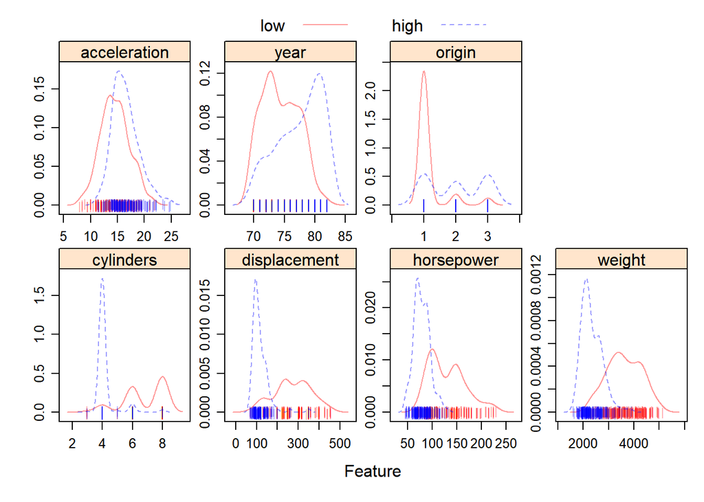

```r
theme1 <- transparentTheme(trans = .4)
trellis.par.set(theme1)

#plot of continuous variables
featurePlot(x = auto[, 1:7],
            y = auto$mpg_cat,
            scales = list(x = list(relation = "free"),
                          y = list(relation = "free")),
            plot = "density", pch = "|",
            auto.key = list(columns = 2))
```

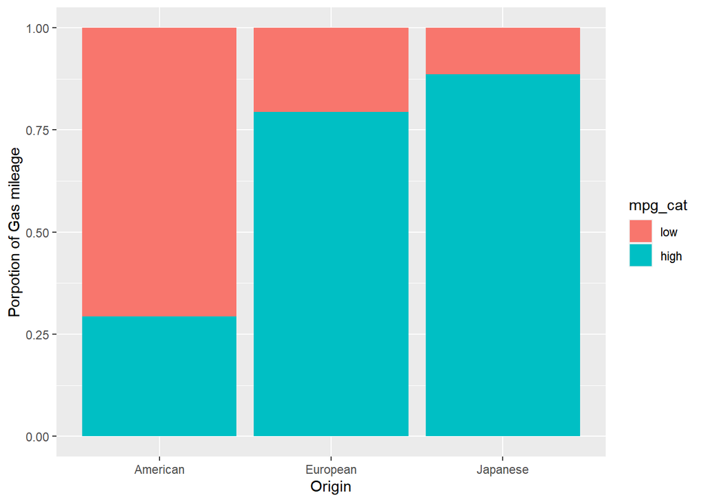

```r
#plot of categorical variables
auto %>%
    mutate(
    origin = case_when(origin == "1" ~ "American",
                       origin == "2" ~ "European",
                       origin == "3" ~ "Japanese"),
    origin = as.factor(origin),
    mpg_cat = as.factor(mpg_cat),
    mpg_cat = fct_relevel(mpg_cat, "low")
  ) %>%
  dplyr::select(-displacement, -horsepower, -weight, -acceleration) %>%
  ggplot(aes(x = origin, fill = mpg_cat)) +
  geom_bar(position = "fill") +
  labs(x = "Origin",
       y = "Porpotion of Gas mileage")
```

We have 7 predictors. the response is mpg_cat.

##b Perform a logistic regression using the training data

```r
# Logistic regression
data2 <-
  auto %>%
  mutate(year = as.factor(year),
         origin = as.factor(origin))
set.seed(2)
rowTrain2 <- createDataPartition(y = data2$mpg_cat,
                                p = 0.7,
                                list = FALSE)

glm.fit <- glm(mpg_cat ~ .,
               data = data2,
               subset = rowTrain2,
               family = binomial(link = "logit"))
summary(glm.fit)
```

```
##
## Call:
## glm(formula = mpg_cat ~ ., family = binomial(link = "logit"),
##     data = data2, subset = rowTrain2)
##
## Deviance Residuals:
##     Min       1Q   Median       3Q      Max
## -1.9111  -0.0212   0.0007   0.0866   3.5170
##
## Coefficients:
##               Estimate Std. Error z value Pr(>|z|)
## (Intercept)  20.010138   5.938817   3.369 0.000753 ***
## cylinders     0.546494   0.722730   0.756 0.449558
## displacement -0.013574   0.020925  -0.649 0.516527
## horsepower   -0.051675   0.039896  -1.295 0.195242
## weight       -0.007017   0.002085  -3.366 0.000762 ***
## acceleration  0.097289   0.208748   0.466 0.641173
## year71       -0.794868   1.580247  -0.503 0.614963
## year72       -1.203297   1.383108  -0.870 0.384303
## year73       -3.053161   1.448186  -2.108 0.035008 *
## year74        1.924270   2.005869   0.959 0.337397
## year75        1.965468   1.483764   1.325 0.185287
## year76        1.519504   1.820423   0.835 0.403887
## year77        0.721718   2.164763   0.333 0.738837
## year78        1.559444   1.392985   1.119 0.262928
## year79        4.098286   1.651616   2.481 0.013088 *
## year80        5.663575   2.080241   2.723 0.006478 **
## year81        4.645895   1.709593   2.718 0.006577 **
## year82        5.297507   1.738005   3.048 0.002303 **
## origin2       1.980973   1.120787   1.767 0.077147 .
## origin3       0.831705   0.998518   0.833 0.404879
## ---
## Signif. codes:  0 '***' 0.001 '**' 0.01 '*' 0.05 '.' 0.1 ' ' 1
##
## (Dispersion parameter for binomial family taken to be 1)
##
##     Null deviance: 382.617  on 275  degrees of freedom
## Residual deviance:  79.828  on 256  degrees of freedom
## AIC: 119.83
##
## Number of Fisher Scoring iterations: 9
```

- Compute the confusion matrix and overall fraction of correct predictions using the test data

```r
#check on the test data
test.pred.prob <- predict(glm.fit, newdata = data2[-rowTrain2,],
                           type = "response")
test.pred <- rep("low", length(test.pred.prob))
test.pred[test.pred.prob>0.5] <- "high"

confusionMatrix(data = as.factor(test.pred),
                reference = data2$mpg_cat[-rowTrain2],
                positive = "high")
```

```
## Confusion Matrix and Statistics
##
##           Reference
## Prediction low high
##       low   55    6
##       high   3   52
##
##                Accuracy : 0.9224
##                  95% CI : (0.8578, 0.9639)
##     No Information Rate : 0.5
##     P-Value [Acc > NIR] : <2e-16
##
##                   Kappa : 0.8448
##
##  Mcnemar's Test P-Value : 0.505
##
##             Sensitivity : 0.8966
##             Specificity : 0.9483
##          Pos Pred Value : 0.9455
##          Neg Pred Value : 0.9016
##              Prevalence : 0.5000
##          Detection Rate : 0.4483
##    Detection Prevalence : 0.4741
##       Balanced Accuracy : 0.9224
##
##        'Positive' Class : high
##
```

Our confusion matrix shows that, overall fraction of correct predictions, is (55 + 52)/(55 + 3 + 6 + 52) = 0.9224 (95% CI: 0.8578, 0.9639) . The confusion matrix also tells us that our no information rate is 50%, which means that if we had no information and made the same class prediction for all observations, our model would be 50% accurate, which is not very ideal. p-value <2e-16 the accuracy is statistically significantly better than no information rate. Sensitivity : 0.8966, Specificity : 0.9483 , with a positive predictive value of 0.9455 and a negative predictive value of 0.9016.Balanced Accuracy : 0.9224.

##c Train a multivariate adaptive regression spline (MARS) model

```r
set.seed(1)
ctrl <- trainControl(method = "repeatedcv",
                     repeats = 5,
                     summaryFunction = twoClassSummary,
                     classProbs = TRUE)

model.mars <- train(x = auto[rowTrain,1:7],
                    y = auto$mpg_cat[rowTrain],
                    method = "earth",
                    tuneGrid = expand.grid(degree = 1:4,
                                           nprune = 2:20),
                    metric = "ROC",
                    trControl = ctrl)
```

[output not shown]

[output cut: 1880 more lines]

[output not shown]

```r
summary(model.mars)
```

```
## Call: earth(x=data.frame[276,7], y=factor.object, keepxy=TRUE,
##             glm=list(family=function.object, maxit=100), degree=4, nprune=9)
##
## GLM coefficients
##                                                               high
## (Intercept)                                             -6.3662029
## h(250-displacement)                                      0.0639294
## h(year-72)                                               0.5113057
## h(4-cylinders) * h(250-displacement)                    -0.1223038
## h(155-displacement) * h(year-72)                        -0.0066747
## h(displacement-173) * h(year-72)                        -0.0190100
## h(displacement-200) * h(year-72)                         0.0188977
## h(250-displacement) * h(weight-2223) * h(79-year)       -0.0000091
## h(displacement-200) * h(acceleration-14.9) * h(year-72)  0.0032547
##
## GLM (family binomial, link logit):
##  nulldev  df       dev  df   devratio     AIC iters converged
##  382.617 275   65.0558 267       0.83   83.06    16         1
##
## Earth selected 9 of 19 terms, and 5 of 7 predictors (nprune=9)
## Termination condition: Reached nk 21
## Importance: displacement, weight, year, cylinders, acceleration, ...
## Number of terms at each degree of interaction: 1 2 4 2
## Earth GCV 0.04126038    RSS 9.720855    GRSq 0.8361523    RSq 0.859118
```

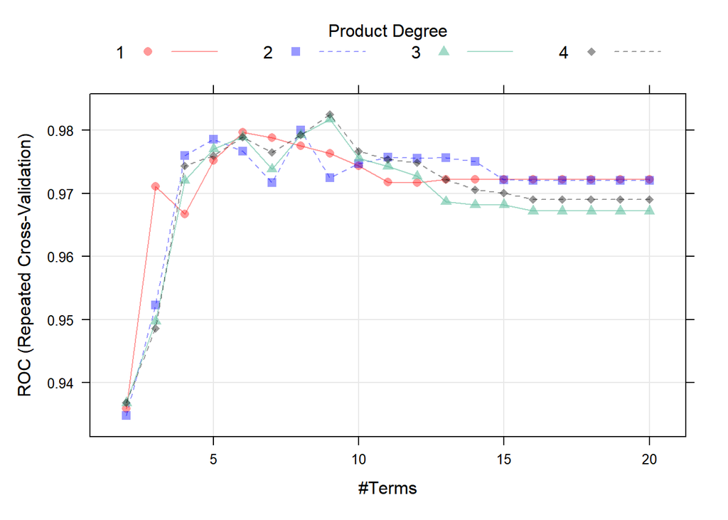

```r
plot(model.mars)
```

```r
model.mars$bestTune
```

```
##    nprune degree
## 65      9      4
```

```r
coef(model.mars$finalModel)
```

```
##                                             (Intercept)
##                                           -6.366203e+00
##                                     h(250-displacement)
##                                            6.392943e-02
##                                              h(year-72)
##                                            5.113057e-01
##                    h(4-cylinders) * h(250-displacement)
##                                           -1.223038e-01
##                        h(155-displacement) * h(year-72)
##                                           -6.674658e-03
##                        h(displacement-200) * h(year-72)
##                                            1.889772e-02
## h(displacement-200) * h(acceleration-14.9) * h(year-72)
##                                            3.254669e-03
##       h(250-displacement) * h(weight-2223) * h(79-year)
##                                           -9.058509e-06
##                        h(displacement-173) * h(year-72)
##                                           -1.900996e-02
```

Earth selected 9 of 19 terms, and 5 of 7 predictors, RSq= 0.859118

##d Perform LDA, Plot the linear discriminants in LDA

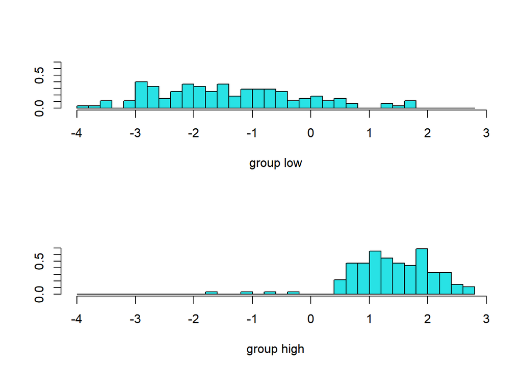

```r
lda.fit <- lda(mpg_cat~., data = auto,
               subset = rowTrain)
plot(lda.fit)
```

```r
lda.fit$scaling
```

```
##                       LD1
## cylinders    -0.240625143
## displacement -0.002823766
## horsepower    0.013012070
## weight       -0.001309113
## acceleration  0.013842643
## year          0.138831306
## origin        0.212917246
```

two classes, so we have k = 2-1 = 1 linear discriminants.

Using caret:

```r
ctrl <- trainControl(method = "repeatedcv", repeats = 5,
                     summaryFunction = twoClassSummary,
                     classProbs = TRUE)

set.seed(11)
model.lda <- train(x = auto[rowTrain,1:7],
                   y = auto$mpg_cat[rowTrain],
                   method = "lda",
                   metric = "ROC",
                   trControl = ctrl)

model.lda$results
```

```
##   parameter       ROC     Sens      Spec      ROCSD    SensSD     SpecSD
## 1      none 0.9588957 0.846044 0.9710989 0.04099279 0.1031846 0.04852375
```

the ROC is 0.9588957, Sensitive 0.846044 and Specificity 0.9710989

##e model comparison, Plot its ROC curve using the test data. Report the AUC and the misclassification error rate.

```r
logit_caret = train(x = rowTrain,
                        y = y,
                        method = "glm",
                        metric = "ROC",
                        trControl = ctrl)

res = resamples(list(Logit = logit_caret ,
                           MARS = model.mars,
                           LDA = model.lda))

summary(res)
```

```
##
## Call:
## summary.resamples(object = res)
##
## Models: Logit, MARS, LDA
## Number of resamples: 50
##
## ROC
##            Min.   1st Qu.    Median      Mean   3rd Qu.      Max. NA's
## Logit 0.6020408 0.6978022 0.7576531 0.7689711 0.8201531 0.9795918    0
## MARS  0.9132653 0.9709425 0.9894035 0.9824538 1.0000000 1.0000000    0
## LDA   0.8214286 0.9438776 0.9629121 0.9588957 0.9948980 1.0000000    0
##
## Sens
##            Min.   1st Qu.    Median      Mean   3rd Qu.      Max. NA's
## Logit 0.4285714 0.6153846 0.7142857 0.6882418 0.7857143 0.9285714    0
## MARS  0.7857143 0.9230769 0.9285714 0.9392308 1.0000000 1.0000000    0
## LDA   0.5384615 0.7857143 0.8571429 0.8460440 0.9285714 1.0000000    0
##
## Spec
##            Min.   1st Qu.    Median      Mean   3rd Qu. Max. NA's
## Logit 0.4285714 0.5714286 0.7032967 0.6724176 0.7554945    1    0
## MARS  0.8461538 0.9285714 0.9285714 0.9549451 1.0000000    1    0
## LDA   0.8461538 0.9285714 1.0000000 0.9710989 1.0000000    1    0
```

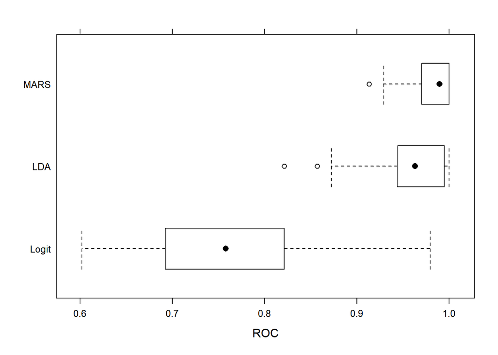

```r
bwplot(res, metric = "ROC")
```

through the resampling, the mars has the highest ROC.

```r
# plot ROC curv, prediction
mars_pred <- predict(model.mars, newdata = auto[-rowTrain, 1:7], type = "prob")[,2]
roc_mars <- roc(auto$mpg_cat[-rowTrain], mars_pred)
#AUC and misclassification error rate
auc_mars = roc_mars$auc[1]
auc_mars
```

```
## [1] 0.9497622
```

```r
test_pred = rep("low", length(mars_pred))
test_pred[mars_pred > 0.5] = "high"
confusionMatrix(data = as.factor(test_pred),
                reference = auto$mpg_cat[-rowTrain],
                positive = "high")
```

```
## Confusion Matrix and Statistics
##
##           Reference
## Prediction low high
##       low   50    6
##       high   8   52
##
##                Accuracy : 0.8793
##                  95% CI : (0.8058, 0.9324)
##     No Information Rate : 0.5
##     P-Value [Acc > NIR] : <2e-16
##
##                   Kappa : 0.7586
##
##  Mcnemar's Test P-Value : 0.7893
##
##             Sensitivity : 0.8966
##             Specificity : 0.8621
##          Pos Pred Value : 0.8667
##          Neg Pred Value : 0.8929
##              Prevalence : 0.5000
##          Detection Rate : 0.4483
##    Detection Prevalence : 0.5172
##       Balanced Accuracy : 0.8793
##
##        'Positive' Class : high
##
```

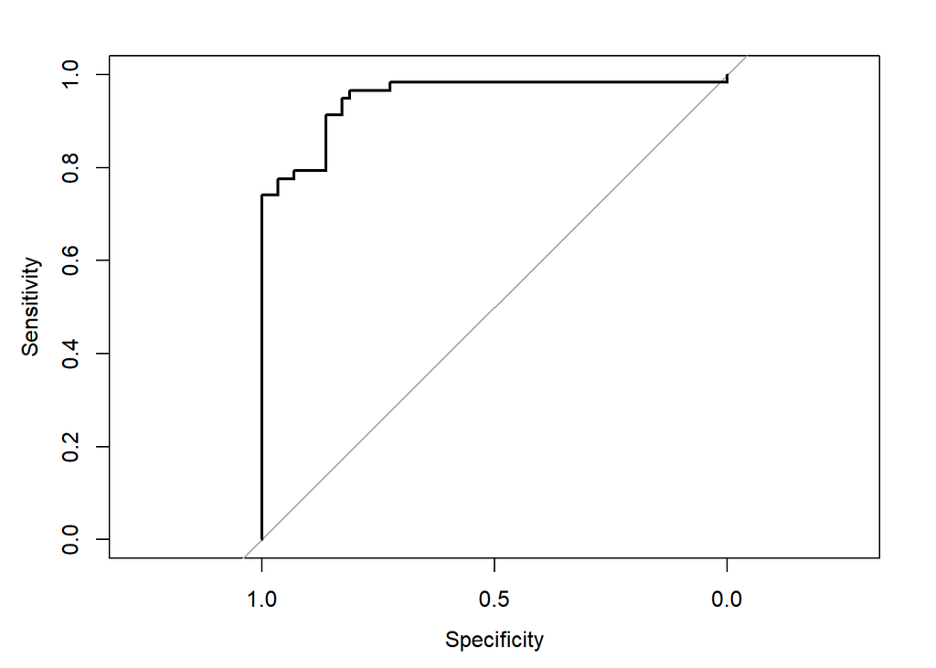

```r
plot(roc_mars, legacy.axis = TRUE)
```